# Student Performance Prediction – Final Integrated Notebook

This notebook is an attempt to combine all work done on this assigment into one single notebook file.

Since I've done quite a lot of copy/pasting between notebooks to create this final version, there is a possibillity for some repetive code throughout this notebook.

This notebook mainly consists of four sections that covers:

- Processing and scrubbing of the dataset.
- Implementation of classing ML models.
- Manually building a ANN model.
- Comparison of testing results on different models.

## Description and exploratory analysis of the 'Student Performance' dataset.

In this document, we'll be using the "Student Performance" dataset which was appended in the course resources to perform exploratory data analysis (EDA) and preprocessing.

### Purpose of the Dataset

According to the dataset description from the source. The dataset has been created in a project that aims to reduce school dropout rates and improve academic success among students.  
The use of machine learning techniques on this dataset can help identify students at risk of dropping out and enable educators to implement targeted interventions.

### Dataset Overview

- The dataset contains information known at the time of student enrollment – academic path, demographics, and social-economic factors.
- Each instance in the dataset represents a student, and the features include various attributes related to their social background and academic performance.
- Dataset consists of 36 features and a target variable with three classes: "Graduate", "Dropout", and "Enrolled".
- It's mentioned that the distributor of the dataset has been training their models with a 80/20 train-test split, but it's not mentioned if any cross-validation was used, or if this was considered a good or bad split.
- There has been performed a rigorous data preprocessing, including handling missing values, remove unexplained outliers, and handle anomalies.

### Feature Description

The dataset contains the following features:

| Feature | Type | Description |
| --- | --- | --- |
| Marital status | Integer | 1 – single 2 – married 3 – widower 4 – divorced 5 – facto union 6 – legally separated |
| Application mode | Integer | 1 - 1st phase - general contingent 2 - Ordinance No. 612/93 5 - 1st phase - special contingent (Azores Island) 7 - Holders of other higher courses 10 - Ordinance No. 854-B/99 15 - International studen… |
| Application order | Integer | Application order (between 0 - first choice; and 9 last choice) |
| Course | Integer | 33 - Biofuel Production Technologies 171 - Animation and Multimedia Design 8014 - Social Service (evening attendance) 9003 - Agronomy 9070 - Communication Design 9085 - Veterinary Nursing 9119 - Infor… |
| "Daytime/evening attendance" | Integer | 1 – daytime 0 - evening |
| Previous qualification | Integer | 1 - Secondary education 2 - Higher education - bachelor's degree 3 - Higher education - degree 4 - Higher education - master's 5 - Higher education - doctorate 6 - Frequency of higher education 9 - 12… |
| Previous qualification (grade) | Continuous | Grade of previous qualification (between 0 and 200) |
| Nacionality | Integer | 1 - Portuguese 2 - German 6 - Spanish 11 - Italian 13 - Dutch 14 - English 17 - Lithuanian 21 - Angolan 22 - Cape Verdean 24 - Guinean 25 - Mozambican 26 - Santomean 32 - Turkish 41 - Brazilian 62 - R… |
| Mother's qualification | Integer | 1 - Secondary Education - 12th Year of Schooling or Eq. 2 - Higher Education - Bachelor's Degree 3 - Higher Education - Degree 4 - Higher Education - Master's 5 - Higher Education - Doctorate 6 - Freq… |
| Father's qualification | Integer | 1 - Secondary Education - 12th Year of Schooling or Eq. 2 - Higher Education - Bachelor's Degree 3 - Higher Education - Degree 4 - Higher Education - Master's 5 - Higher Education - Doctorate 6 - Freq… |
| Mother's occupation | Integer | 0 - Student 1 - Representatives of the Legislative Power and Executive Bodies, Directors, Directors and Executive Managers 2 - Specialists in Intellectual and Scientific Activities 3 - Intermediate Le… |
| Father's occupation | Integer | 0 - Student 1 - Representatives of the Legislative Power and Executive Bodies, Directors, Directors and Executive Managers 2 - Specialists in Intellectual and Scientific Activities 3 - Intermediate Le… |
| Admission grade | Continuous | Admission grade (between 0 and 200) |
| Displaced | Integer | 1 – yes 0 – no |
| Educational special needs | Integer | 1 – yes 0 – no |
| Debtor | Integer | 1 – yes 0 – no |
| Tuition fees up to date | Integer | 1 – yes 0 – no |
| Gender | Integer | 1 – male 0 – female |
| Scholarship holder | Integer | 1 – yes 0 – no |
| Age at enrollment | Integer | Age of studend at enrollment |
| International | Integer | 1 – yes 0 – no |
| Curricular units 1st sem (credited) | Integer | Number of curricular units credited in the 1st semester |
| Curricular units 1st sem (enrolled) | Integer | Number of curricular units enrolled in the 1st semester |
| Curricular units 1st sem (evaluations) | Integer | Number of evaluations to curricular units in the 1st semester |
| Curricular units 1st sem (approved) | Integer | Number of curricular units approved in the 1st semester |
| Curricular units 1st sem (grade) | Integer | Grade average in the 1st semester (between 0 and 20) |
| Curricular units 1st sem (without evaluations) | Integer | Number of curricular units without evalutions in the 1st semester |
| Curricular units 2nd sem (credited) | Integer | Number of curricular units credited in the 2nd semester |
| Curricular units 2nd sem (enrolled) | Integer | Number of curricular units enrolled in the 2nd semester |
| Curricular units 2nd sem (evaluations) | Integer | Number of evaluations to curricular units in the 2nd semester |
| Curricular units 2nd sem (approved) | Integer | Number of curricular units approved in the 2nd semester |
| Curricular units 2nd sem (grade) | Integer | Grade average in the 2nd semester (between 0 and 20) |
| Curricular units 2nd sem (without evaluations) | Integer | Number of curricular units without evalutions in the 1st semester |
| Unemployment rate | Continuous | Unemployment rate (%) |
| Inflation rate | Continuous | Inflation rate (%) |
| GDP | Continuous | GDP |

### Target Variable

The target variable for this dataset is labled as "Target" and it has three classes:

- "Graduate" – indicates that the student has successfully completed their academic program.
- "Dropout" – indicates that the student has discontinued their studies before completion.
- "Enrolled" – indicates that the student is currently enrolled in their academic program.

### Exploratory Data Analysis (EDA)

In this section, we will perform exploratory data analysis to understand the distribution of features and the target variable, as well as identify any potential correlations or patterns in the data.

### Data import

We'll start by importing the necessary libraries to analyze the dataset and loading the dataset with pandas.  
For this analysis, we'll be dropping the target variable from the dataset to focus on the features only.

```python
import pandas as pd
import numpy as np
import matplotlib.pyplot as plt
import seaborn as sb
```

### Custom Functions for Analysis

To facilitate the analysis of the dataset, we'll define some custom functions that can help us visualize and understand the data better.

```python
def get_df_name(df):
    name =[x for x in globals() if globals()[x] is df][0]
    return name

def corr_matrix(df):
    numCorr1 = df.corr()
    fig, ax = plt.subplots(1,1, figsize=(23,7))
    sb.heatmap(numCorr1, annot=True, cmap='coolwarm', ax=ax)
    ax.set_title(get_df_name(df))

def target_bar(df1):
    fig, ax = plt.subplots(1, 1, figsize=(10, 5))
    sb.countplot(x="Target", data=df1, ax=ax)
    ax.set_title(get_df_name(df1))
    ax.set_xlabel("Target")
    ax.set_ylabel("Count")
    plt.tight_layout()
```

```python
student_df = pd.read_csv("../data/student_predictions.csv", sep=";")
student_df_X = student_df.drop(columns=["Target"])
student_df_y = student_df[["Target"]]
student_df_X.head()
```

|  | Marital status | Application mode | Application order | Course | Daytime/evening attendance | Previous qualification | Previous qualification (grade) | Nacionality | Mother's qualification | Father's qualification | ... | Curricular units 1st sem (without evaluations) | Curricular units 2nd sem (credited) | Curricular units 2nd sem (enrolled) | Curricular units 2nd sem (evaluations) | Curricular units 2nd sem (approved) | Curricular units 2nd sem (grade) | Curricular units 2nd sem (without evaluations) | Unemployment rate | Inflation rate | GDP |
| --- | --- | --- | --- | --- | --- | --- | --- | --- | --- | --- | --- | --- | --- | --- | --- | --- | --- | --- | --- | --- | --- |
| 0 | 1 | 17 | 5 | 171 | 1 | 1 | 122.0 | 1 | 19 | 12 | ... | 0 | 0 | 0 | 0 | 0 | 0.000000 | 0 | 10.8 | 1.4 | 1.74 |
| 1 | 1 | 15 | 1 | 9254 | 1 | 1 | 160.0 | 1 | 1 | 3 | ... | 0 | 0 | 6 | 6 | 6 | 13.666667 | 0 | 13.9 | -0.3 | 0.79 |
| 2 | 1 | 1 | 5 | 9070 | 1 | 1 | 122.0 | 1 | 37 | 37 | ... | 0 | 0 | 6 | 0 | 0 | 0.000000 | 0 | 10.8 | 1.4 | 1.74 |
| 3 | 1 | 17 | 2 | 9773 | 1 | 1 | 122.0 | 1 | 38 | 37 | ... | 0 | 0 | 6 | 10 | 5 | 12.400000 | 0 | 9.4 | -0.8 | -3.12 |
| 4 | 2 | 39 | 1 | 8014 | 0 | 1 | 100.0 | 1 | 37 | 38 | ... | 0 | 0 | 6 | 6 | 6 | 13.000000 | 0 | 13.9 | -0.3 | 0.79 |

5 rows × 36 columns

### Validation of Data types

#### Dataset Information

It's important to validate that the data types of each feature are appropriate for analysis.  
We can use the `info()` method from pandas to check the data types and non-null counts of each column in the dataset.  
From the output in the next cell, we can see that all features have the correct data types and there are no missing values in the dataset.

```python
student_df_X.info()
```

```
<class 'pandas.core.frame.DataFrame'>
RangeIndex: 4424 entries, 0 to 4423
Data columns (total 36 columns):
 #   Column                                          Non-Null Count  Dtype
---  ------                                          --------------  -----
 0   Marital status                                  4424 non-null   int64
 1   Application mode                                4424 non-null   int64
 2   Application order                               4424 non-null   int64
 3   Course                                          4424 non-null   int64
 4   Daytime/evening attendance                      4424 non-null   int64
 5   Previous qualification                          4424 non-null   int64
 6   Previous qualification (grade)                  4424 non-null   float64
 7   Nacionality                                     4424 non-null   int64
 8   Mother's qualification                          4424 non-null   int64
 9   Father's qualification                          4424 non-null   int64
```

[output cut: 28 more lines]

#### Dataset Description

Next we'll use the `describe()` method from pandas to get a statistical summary of the numerical features in the dataset. Here we can see the count, mean, standard deviation, minimum, maximum, and quartiles for each numerical feature.

```python
student_df_X.describe()
```

|  | Marital status | Application mode | Application order | Course | Daytime/evening attendance | Previous qualification | Previous qualification (grade) | Nacionality | Mother's qualification | Father's qualification | ... | Curricular units 1st sem (without evaluations) | Curricular units 2nd sem (credited) | Curricular units 2nd sem (enrolled) | Curricular units 2nd sem (evaluations) | Curricular units 2nd sem (approved) | Curricular units 2nd sem (grade) | Curricular units 2nd sem (without evaluations) | Unemployment rate | Inflation rate | GDP |
| --- | --- | --- | --- | --- | --- | --- | --- | --- | --- | --- | --- | --- | --- | --- | --- | --- | --- | --- | --- | --- | --- |
| count | 4424.000000 | 4424.000000 | 4424.000000 | 4424.000000 | 4424.000000 | 4424.000000 | 4424.000000 | 4424.000000 | 4424.000000 | 4424.000000 | ... | 4424.000000 | 4424.000000 | 4424.000000 | 4424.000000 | 4424.000000 | 4424.000000 | 4424.000000 | 4424.000000 | 4424.000000 | 4424.000000 |
| mean | 1.178571 | 18.669078 | 1.727848 | 8856.642631 | 0.890823 | 4.577758 | 132.613314 | 1.873192 | 19.561935 | 22.275316 | ... | 0.137658 | 0.541817 | 6.232143 | 8.063291 | 4.435805 | 10.230206 | 0.150316 | 11.566139 | 1.228029 | 0.001969 |
| std | 0.605747 | 17.484682 | 1.313793 | 2063.566416 | 0.311897 | 10.216592 | 13.188332 | 6.914514 | 15.603186 | 15.343108 | ... | 0.690880 | 1.918546 | 2.195951 | 3.947951 | 3.014764 | 5.210808 | 0.753774 | 2.663850 | 1.382711 | 2.269935 |
| min | 1.000000 | 1.000000 | 0.000000 | 33.000000 | 0.000000 | 1.000000 | 95.000000 | 1.000000 | 1.000000 | 1.000000 | ... | 0.000000 | 0.000000 | 0.000000 | 0.000000 | 0.000000 | 0.000000 | 0.000000 | 7.600000 | -0.800000 | -4.060000 |
| 25% | 1.000000 | 1.000000 | 1.000000 | 9085.000000 | 1.000000 | 1.000000 | 125.000000 | 1.000000 | 2.000000 | 3.000000 | ... | 0.000000 | 0.000000 | 5.000000 | 6.000000 | 2.000000 | 10.750000 | 0.000000 | 9.400000 | 0.300000 | -1.700000 |
| 50% | 1.000000 | 17.000000 | 1.000000 | 9238.000000 | 1.000000 | 1.000000 | 133.100000 | 1.000000 | 19.000000 | 19.000000 | ... | 0.000000 | 0.000000 | 6.000000 | 8.000000 | 5.000000 | 12.200000 | 0.000000 | 11.100000 | 1.400000 | 0.320000 |
| 75% | 1.000000 | 39.000000 | 2.000000 | 9556.000000 | 1.000000 | 1.000000 | 140.000000 | 1.000000 | 37.000000 | 37.000000 | ... | 0.000000 | 0.000000 | 7.000000 | 10.000000 | 6.000000 | 13.333333 | 0.000000 | 13.900000 | 2.600000 | 1.790000 |
| max | 6.000000 | 57.000000 | 9.000000 | 9991.000000 | 1.000000 | 43.000000 | 190.000000 | 109.000000 | 44.000000 | 44.000000 | ... | 12.000000 | 19.000000 | 23.000000 | 33.000000 | 20.000000 | 18.571429 | 12.000000 | 16.200000 | 3.700000 | 3.510000 |

8 rows × 36 columns

### Feature Types Summary

Based on the dataset information, we can summarize the feature types as follows:

| Type | Examples | Notes |
| --- | --- | --- |
| **Categorical (Encoded as Integers)** | `Marital status`, `Application mode`, `Course`, `Previous qualification`, `Nationality`, `Mother’s qualification`, `Father’s qualification`, `Mother’s occupation`, `Father’s occupation`, `Gender`, `Di… | Encoded labels — must be **decoded or one-hot encoded** for ML; interpret using frequencies rather than numeric averages. |
| **Ordinal** | `Application order` | 0 → first choice, 9 → last choice → ordered meaning (lower = higher preference). |
| **Continuous (Numeric)** | `Admission grade`, `Previous qualification (grade)`, `Age at enrollment`, `Unemployment rate`, `Inflation rate`, `GDP`, semester-related grades and counts | Suitable for correlation and distribution analysis. |
| **Performance / Academic Metrics (Continuous/Count)** | `Curricular units 1st/2nd sem (enrolled, approved, grade, evaluations, credited, without evaluations)` | Likely the most informative variables for success prediction. |

### Feature correlation analysis

To understand the relationships between different features and the target variable, we can perform correlation analysis.  
We can use correlation matrices and visualizations such as heatmaps to identify any strong correlations between features.  
This can help us identify which features may be more relevant for predicting student performance.

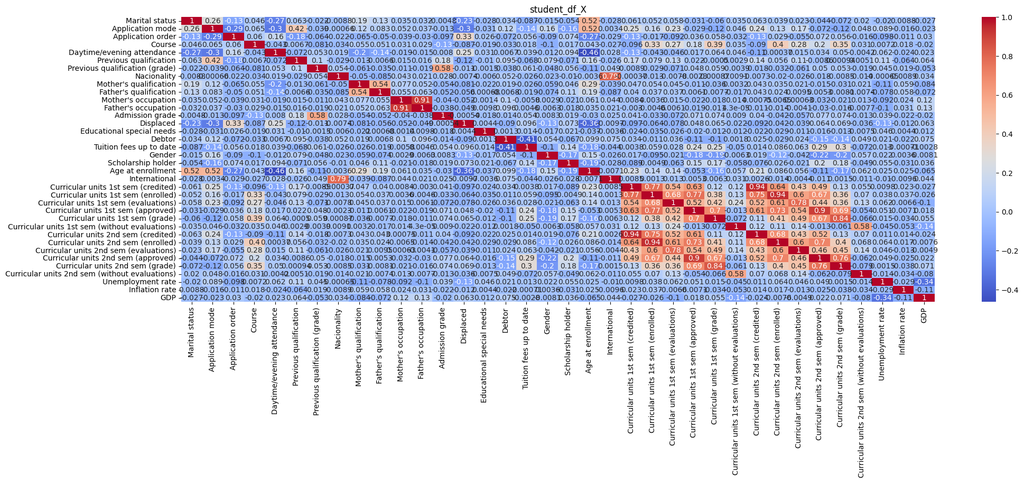

```python
corr_matrix(student_df_X)
```

### Heatmap of Feature Correlations

The heatmap above shows the correlation coefficients between different features in the dataset. We observe a high correlation between "Mother/Father's occupation" which may indicate that parental occupation has a significant influence on student performance. We might consider merging these two features or creating a new feature that captures the combined effect of parental occupation on student performance.  
There's quite high correlation between various columns related to curricular units in both semesters. From the heatmap and the contect of the dataset, the following observations can be made:

| Pair | Correlation | Interpretation |
| --- | --- | --- |
| `1st sem (enrolled)` ↔ `1st sem (evaluations)` | **0.68** | Students enrolled in more courses take more evaluations. |
| `1st sem (approved)` ↔ `1st sem (grade)` | **0.70** | More approvals relate to higher average grades. |
| `1st sem (approved)` ↔ `2nd sem (approved)` | **0.90** | Good performance in one semester predicts good performance in the next. |
| `1st sem (without evaluations)` ↔ other metrics | **negative** | Not being evaluated (e.g., dropouts, absences) correlates with *lower* grades and fewer approvals. |

We might consider combining some of these correlated features into composite scores or selecting the most informative ones to reduce redundancy in the dataset.

### Feature Distributions

To understand the distribution of each feature in the dataset, we can visualize them using histograms or density plots.  
This can help us identify any skewness, outliers, or unusual patterns in the data.  
In the histograms below, we can see the distributions of all features in the dataset. Here we can see that there are several features with skewed distributions which may require transformation or normalization before using them in machine learning models.  
Such patterns suggest that transformations (e.g., log or power scaling), normalization, or categorical re-encoding may be required to improve model performance. Additionally, features with near-constant values or excessive sparsity may contribute little predictive power and could be considered for removal.

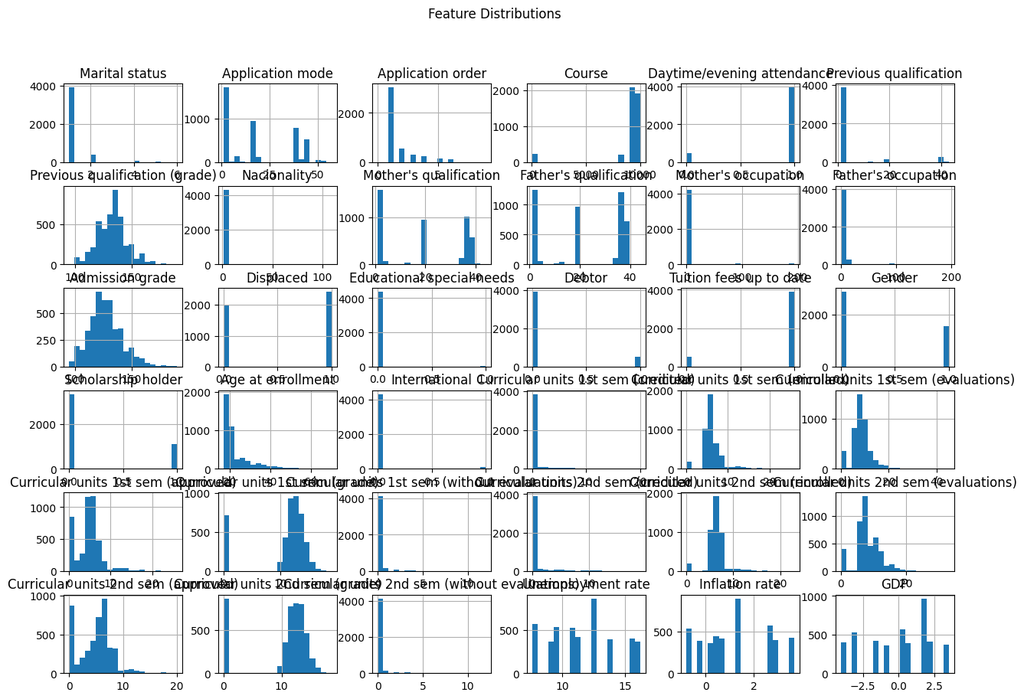

```python
student_df_X.hist(figsize=(15,10), bins=20)
plt.suptitle("Feature Distributions")
```

### Counting unique values for categorical features

To further understand the categorical features in the dataset, we can count the number of unique values for each categorical feature.  
This can help us identify features with high cardinality that may require special handling during preprocessing.  
In the cell below, we count and display the number of unique values for each potential categorical feature.

```python
for col in student_df_X.columns:
    unique_vals = student_df_X[col].nunique()
    if unique_vals < 10:
        print(f"{col}: {unique_vals} unique values — likely categorical")
```

```
Marital status: 6 unique values — likely categorical
Application order: 8 unique values — likely categorical
Daytime/evening attendance: 2 unique values — likely categorical
Displaced: 2 unique values — likely categorical
Educational special needs: 2 unique values — likely categorical
Debtor: 2 unique values — likely categorical
Tuition fees up to date: 2 unique values — likely categorical
Gender: 2 unique values — likely categorical
Scholarship holder: 2 unique values — likely categorical
International: 2 unique values — likely categorical
Inflation rate: 9 unique values — likely categorical
```

```python
student_categorical = student_df_X[['Marital status', 'Application order', 'Daytime/evening attendance', 'Displaced', 'Educational special needs', 'Debtor', 'Tuition fees up to date', 'Gender', 'Scholarship holder', 'International', 'Inflation rate']]
student_categorical = student_categorical.astype('category')
student_numerical = student_df_X.drop(columns=student_categorical.columns)
```

### Countplots for Categorical Features

To visualize the distribution of categorical features in the dataset, we can create countplots for each categorical feature.  
This can help us understand the frequency of each category and identify any imbalances in the data.  
In the cell below, we create countplots for all categorical features in the dataset.

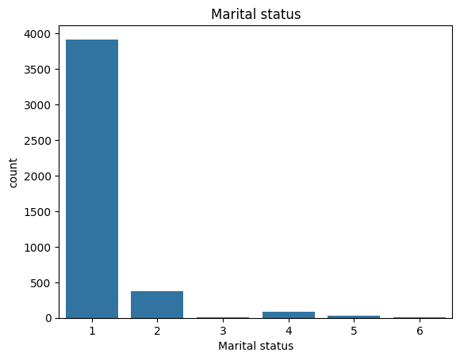

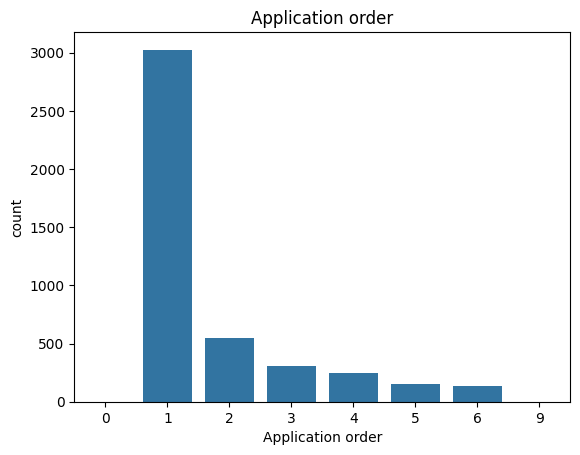

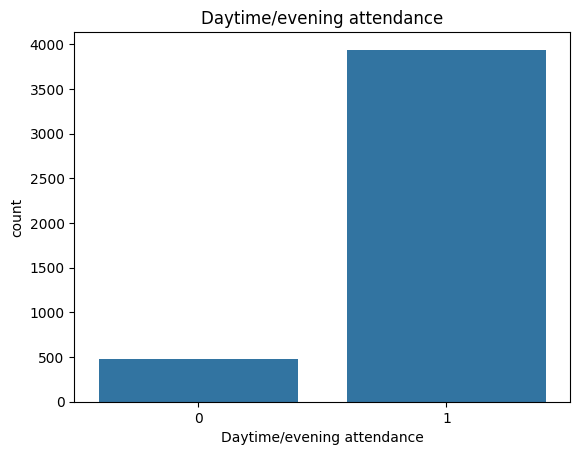

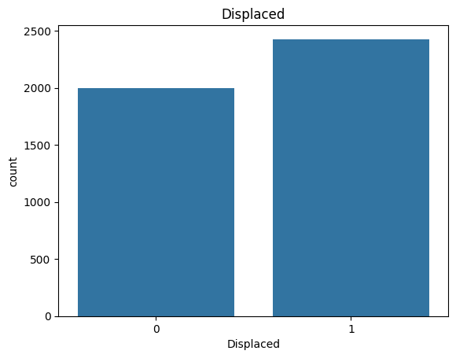

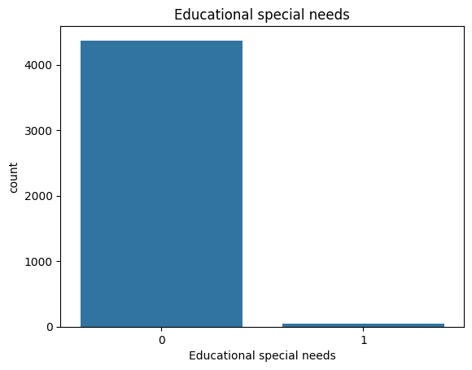

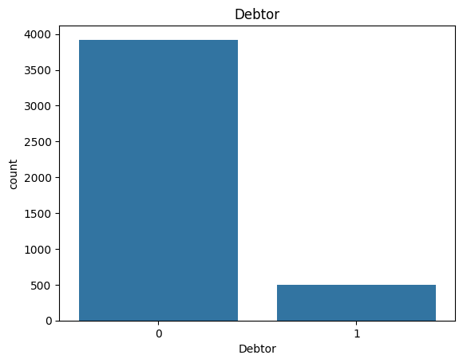

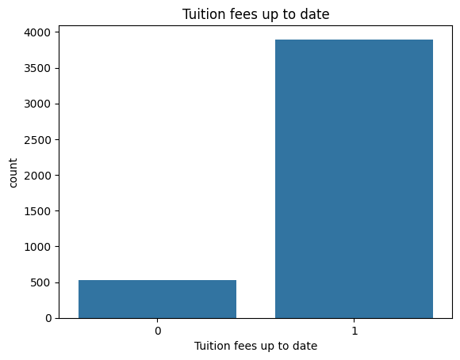

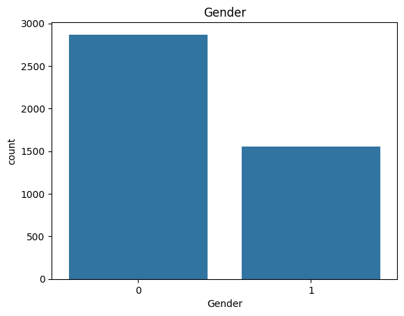

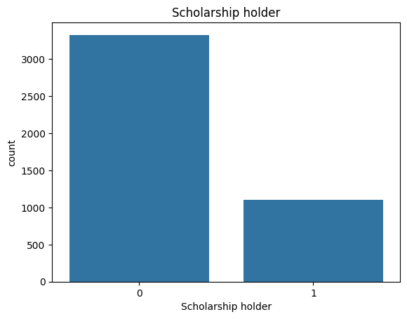

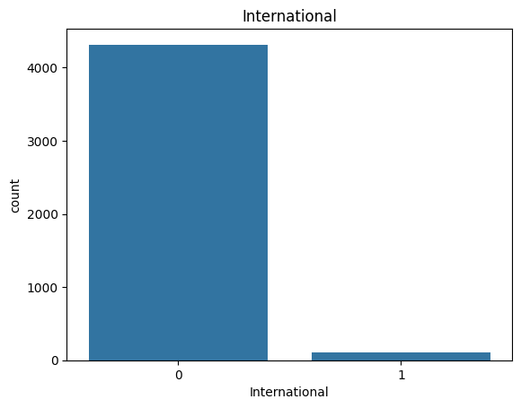

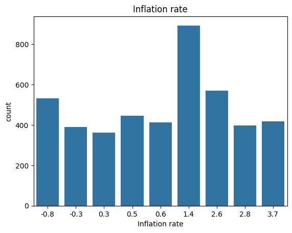

```python
for col in student_categorical.columns:
    sb.countplot(x=student_categorical[col])
    plt.title(col)
    plt.show()
```

From the result here we can see that all features except `Inflation rate` fits into the categorical data type. This feature should be treated as continuous and will be moved to the numerical features.

```python
student_numerical['Inflation rate'] = student_categorical['Inflation rate'].astype('float64')
student_categorical = student_categorical.drop(columns=['Inflation rate'])
```

### Boxplots for Numerical Features

To further analyze the numerical features in the dataset, we can create boxplots for each numerical feature.

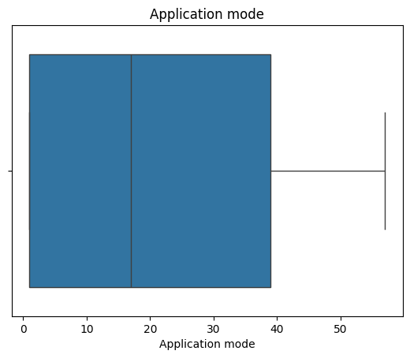

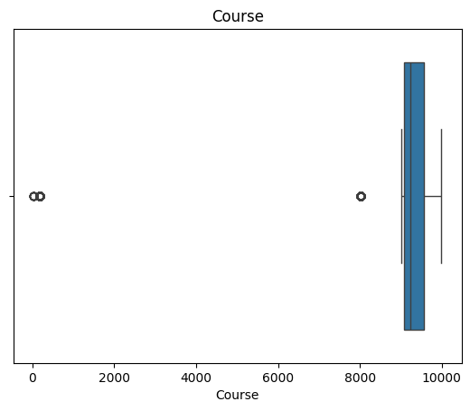

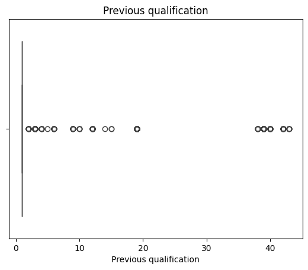

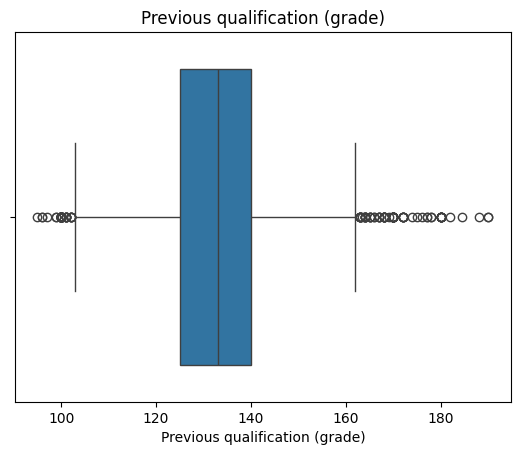

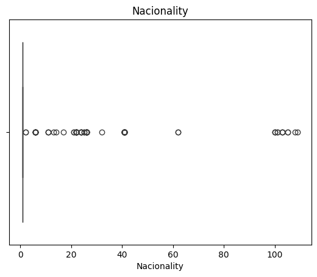

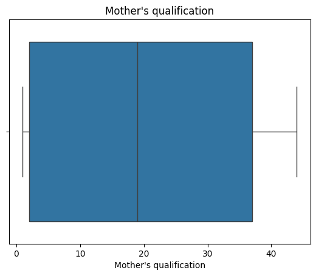

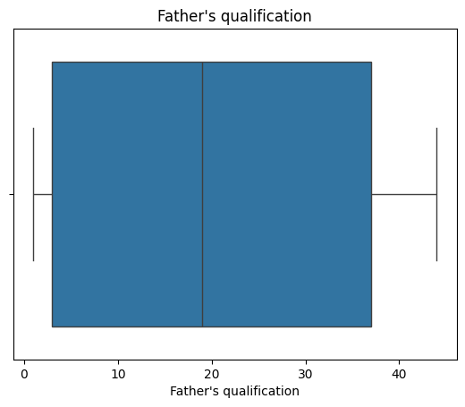

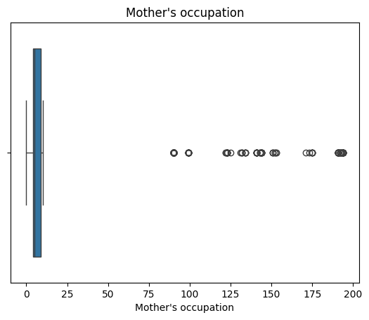

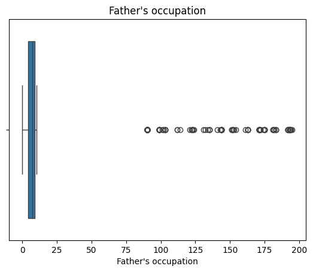

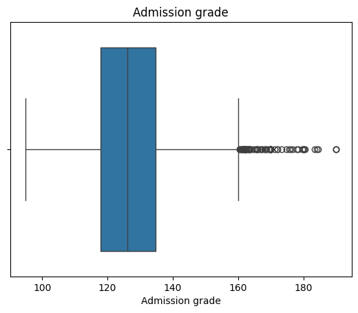

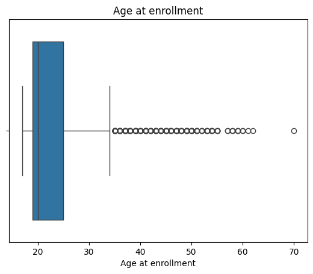

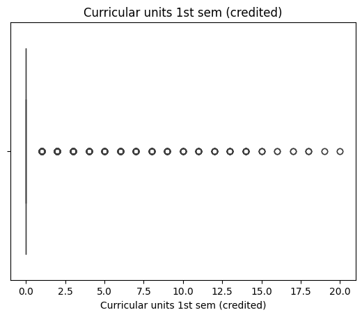

[14 more figures not shown]

```python
for col in student_numerical.select_dtypes(include=np.number).columns:
    sb.boxplot(x=student_numerical[col])
    plt.title(col)
    plt.show()
```

#### Target Variable Distribution

To understand the distribution of the target variable, we can visualize it using a bar plot.

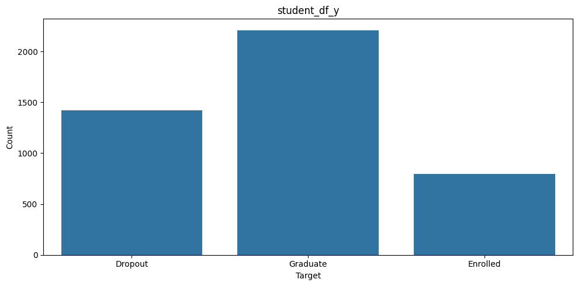

```python
target_bar(student_df_y)
```

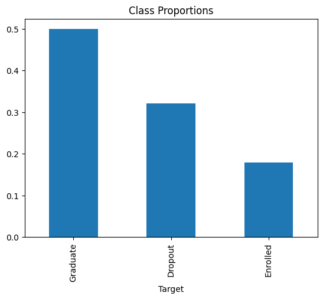

```python
student_df["Target"].value_counts(normalize=True).plot(kind='bar', title="Class Proportions")
```

Here we can see the distribution of targets are slightly imbalanced, with "Graduate" being the most common class, followed by "Dropout" and "Enrolled".  
This indicates that predictions might be biased towards the "Graduate" class, and we may need to consider techniques to address this imbalance during model training. Here we could consider methods such as SMOTE (Synthetic Minority Over-sampling Technique) or class weighting to ensure that the model pays adequate attention to the minority classes during training.

### Processing dataset

Based on the exploratory data analysis, we can start outlining the following preprocessing steps to prepare the dataset for machine learning:

### Feature Selection

#### Categorical Features to Drop

Based on the exploratory data analysis, we can consider dropping the following features from the dataset:

- `Marital status` - has very low variance with almost all students being single. This feature is unlikely to provide meaningful information for predicting student performance.
- `Daytime/evening attendance` – has very low variance with almost all students attending daytime classes. This feature is unlikely to provide meaningful information for predicting student performance.
- `Educational special needs` – has very low variance with almost all students not having special needs. This feature is unlikely to provide meaningful information for predicting student performance.
- `International` – has very low variance with almost all students being non-international. This feature is unlikely to provide meaningful information for predicting student performance.

```python
student_categorical = student_categorical.drop(columns=['Marital status', 'Daytime/evening attendance', 'Educational special needs', 'International'])

student_categorical.describe()
```

|  | Application order | Displaced | Debtor | Tuition fees up to date | Gender | Scholarship holder |
| --- | --- | --- | --- | --- | --- | --- |
| count | 4424 | 4424 | 4424 | 4424 | 4424 | 4424 |
| unique | 8 | 2 | 2 | 2 | 2 | 2 |
| top | 1 | 1 | 0 | 1 | 0 | 0 |
| freq | 3026 | 2426 | 3921 | 3896 | 2868 | 3325 |

#### Numerical Feature Adjustment

By evaluating the distributions of the features with heatmaps and boxplots. The following adjustments will be made:

- `Curricular units 1st sem (credited)` and `Curricular units 2nd sem (credited)` - With a corr elation of 0.94, these two features are highly correlated. We can consider combining them into a single feature representing the total credited units across both semesters.
- `Curricular units 1st sem (enrolled)` and `Curricular units 2nd sem (enrolled)` - With a correlation of 0.94, these features these two features are highly correlated. We can consider combining them into a single feature representing the total enrolled units across both semesters.
- `Curricular units 1st sem (evaluations)` and `Curricular units 2nd sem (evaluations)` - With a correlation of 0.78, these features these two features are highly correlated. We can consider combining them into a single feature representing the total evaluations across both semesters.
- `Curricular units 1st sem (approved)` and `Curricular units 2nd sem (approved)` - With a correlation of 0.90, these features these two features are highly correlated. We can consider combining them into a single feature representing the total approved units across both semesters.
- `Curricular units 1st sem (grade)` and `Curricular units 2nd sem (grade)` - With a correlation of 0.84, these features these two features are highly correlated. We can consider combining them into a single feature representing the average grade across both semesters.
- `Mother's occupation` and `Father's occupation` - With a correlation of 0.91, these two features are highly correlated. We might consider merging these two features or creating a new feature that captures the combined effect of parental occupation on student performance.
- `International` and `Nationality` - With a correlation of 0.79, these two features are correlated. Since `International` has very low variance, we can consider dropping this feature and relying on `Nationality` to capture any relevant information about international students.

It's worth mentioning that there are also observed numerical features with a lot of outliers, such as `Course` and `Previous qualifications`. These features may require further investigation and potential outlier handling techniques to ensure they do not adversely affect model performance.

```python
# Combine `Curricular units 1st sem (credited)` and `Curricular units 2nd sem (credited)`
for col1, col2 in [('Curricular units 1st sem (credited)', 'Curricular units 2nd sem (credited)')]:
    student_numerical['Total credited units'] = (student_numerical[col1] + student_numerical[col2]) / 2
    student_numerical = student_numerical.drop(columns=[col1, col2])

# Combine `Curricular units 1st sem (enrolled)` and `Curricular units 2nd sem (enrolled)`
for col1, col2 in [('Curricular units 1st sem (enrolled)', 'Curricular units 2nd sem (enrolled)')]:
    student_numerical['Total enrolled units'] = (student_numerical[col1] + student_numerical[col2]) / 2
    student_numerical = student_numerical.drop(columns=[col1, col2])

# Combine `Curricular units 1st sem (evaluations)` and `Curricular units 2nd sem (evaluations)`
for col1, col2 in [('Curricular units 1st sem (evaluations)', 'Curricular units 2nd sem (evaluations)')]:
    student_numerical['Total evaluations'] = (student_numerical[col1] + student_numerical[col2]) / 2
    student_numerical = student_numerical.drop(columns=[col1, col2])

# Combine `Curricular units 1st sem (approved)` and `Curricular units 2nd sem (approved)`
for col1, col2 in [('Curricular units 1st sem (approved)', 'Curricular units 2nd sem (approved)')]:
    student_numerical['Total approved units'] = (student_numerical[col1] + student_numerical[col2]) / 2
    student_numerical = student_numerical.drop(columns=[col1, col2])

# Combine `Curricular units 1st sem (grade)` and `Curricular units 2nd sem (grade)`
for col1, col2 in [('Curricular units 1st sem (grade)', 'Curricular units 2nd sem (grade)')]:
    student_numerical['Average grade'] = (student_numerical[col1] + student_numerical[col2]) / 2
    student_numerical = student_numerical.drop(columns=[col1, col2])

# Combine `Mother's occupation` and `Father's occupation`
for col1, col2 in [("Mother's occupation", "Father's occupation")]:
    student_numerical['Combined parental occupation'] = student_numerical[col1] + student_numerical[col2] / 2
    student_numerical = student_numerical.drop(columns=[col1, col2])
```

```python
student_numerical.describe()
```

|  | Application mode | Course | Previous qualification | Previous qualification (grade) | Nacionality | Mother's qualification | Father's qualification | Admission grade | Age at enrollment | Curricular units 1st sem (without evaluations) | Curricular units 2nd sem (without evaluations) | Unemployment rate | GDP | Inflation rate | Total credited units | Total enrolled units | Total evaluations | Total approved units | Average grade | Combined parental occupation |
| --- | --- | --- | --- | --- | --- | --- | --- | --- | --- | --- | --- | --- | --- | --- | --- | --- | --- | --- | --- | --- |
| count | 4424.000000 | 4424.000000 | 4424.000000 | 4424.000000 | 4424.000000 | 4424.000000 | 4424.000000 | 4424.000000 | 4424.000000 | 4424.000000 | 4424.000000 | 4424.000000 | 4424.000000 | 4424.000000 | 4424.000000 | 4424.000000 | 4424.000000 | 4424.000000 | 4424.000000 | 4424.000000 |
| mean | 18.669078 | 8856.642631 | 4.577758 | 132.613314 | 1.873192 | 19.561935 | 22.275316 | 126.978119 | 23.265145 | 0.137658 | 0.150316 | 11.566139 | 0.001969 | 1.228029 | 0.625904 | 6.251356 | 8.181171 | 4.571203 | 10.435514 | 16.477057 |
| std | 17.484682 | 2063.566416 | 10.216592 | 13.188332 | 6.914514 | 15.603186 | 15.343108 | 14.482001 | 7.587816 | 0.690880 | 0.753774 | 2.663850 | 2.269935 | 1.382711 | 2.110120 | 2.304411 | 3.832493 | 2.980306 | 4.818530 | 38.277061 |
| min | 1.000000 | 33.000000 | 1.000000 | 95.000000 | 1.000000 | 1.000000 | 1.000000 | 95.000000 | 17.000000 | 0.000000 | 0.000000 | 7.600000 | -4.060000 | -0.800000 | 0.000000 | 0.000000 | 0.000000 | 0.000000 | 0.000000 | 0.000000 |
| 25% | 1.000000 | 9085.000000 | 1.000000 | 125.000000 | 1.000000 | 2.000000 | 3.000000 | 117.900000 | 19.000000 | 0.000000 | 0.000000 | 9.400000 | -1.700000 | 0.300000 | 0.000000 | 5.000000 | 6.500000 | 2.500000 | 11.000000 | 6.500000 |
| 50% | 17.000000 | 9238.000000 | 1.000000 | 133.100000 | 1.000000 | 19.000000 | 19.000000 | 126.100000 | 20.000000 | 0.000000 | 0.000000 | 11.100000 | 0.320000 | 1.400000 | 0.000000 | 6.000000 | 8.000000 | 5.000000 | 12.250000 | 9.000000 |
| 75% | 39.000000 | 9556.000000 | 1.000000 | 140.000000 | 1.000000 | 37.000000 | 37.000000 | 134.800000 | 25.000000 | 0.000000 | 0.000000 | 13.900000 | 1.790000 | 2.600000 | 0.000000 | 7.000000 | 10.000000 | 6.000000 | 13.266667 | 13.000000 |
| max | 57.000000 | 9991.000000 | 43.000000 | 190.000000 | 109.000000 | 44.000000 | 44.000000 | 190.000000 | 70.000000 | 12.000000 | 12.000000 | 16.200000 | 3.510000 | 3.700000 | 19.500000 | 23.000000 | 36.000000 | 21.500000 | 18.283654 | 291.000000 |

```python
student_df_X_processed = pd.concat([student_numerical, student_categorical], axis=1)
student_df_X_processed.info()
```

```
<class 'pandas.core.frame.DataFrame'>
RangeIndex: 4424 entries, 0 to 4423
Data columns (total 26 columns):
 #   Column                                          Non-Null Count  Dtype
---  ------                                          --------------  -----
 0   Application mode                                4424 non-null   int64
 1   Course                                          4424 non-null   int64
 2   Previous qualification                          4424 non-null   int64
 3   Previous qualification (grade)                  4424 non-null   float64
 4   Nacionality                                     4424 non-null   int64
 5   Mother's qualification                          4424 non-null   int64
 6   Father's qualification                          4424 non-null   int64
 7   Admission grade                                 4424 non-null   float64
 8   Age at enrollment                               4424 non-null   int64
 9   Curricular units 1st sem (without evaluations)  4424 non-null   int64
```

[output cut: 18 more lines]

### Evaluation of new dataframe

After performing the preprocessing steps, we can evaluate the new dataframe to ensure that it is ready for machine learning models.

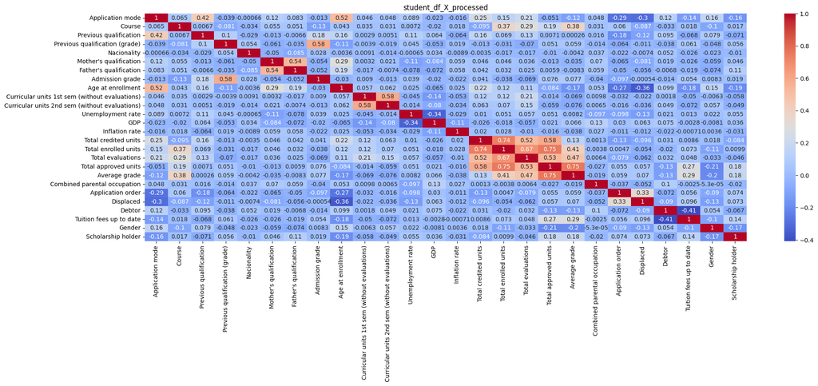

```python
corr_matrix(student_df_X_processed)
```

We can observe that there still exists some high correlations between features, particularly among the curricular unit metrics. However, the overall structure of the dataframe appears more suitable for machine learning tasks than the original dataset.

```python
student_df_processed = pd.concat([student_df_X_processed, student_df_y], axis=1)
student_df_processed.info()
```

```
<class 'pandas.core.frame.DataFrame'>
RangeIndex: 4424 entries, 0 to 4423
Data columns (total 27 columns):
 #   Column                                          Non-Null Count  Dtype
---  ------                                          --------------  -----
 0   Application mode                                4424 non-null   int64
 1   Course                                          4424 non-null   int64
 2   Previous qualification                          4424 non-null   int64
 3   Previous qualification (grade)                  4424 non-null   float64
 4   Nacionality                                     4424 non-null   int64
 5   Mother's qualification                          4424 non-null   int64
 6   Father's qualification                          4424 non-null   int64
 7   Admission grade                                 4424 non-null   float64
 8   Age at enrollment                               4424 non-null   int64
 9   Curricular units 1st sem (without evaluations)  4424 non-null   int64
```

[output cut: 19 more lines]

### Reinstate target variable

Finally, we can reinstate the target variable back into the processed dataframe to prepare it for machine learning tasks.

### Exporting Processed Dataset

After completing the preprocessing steps, we can export the processed dataset for use in machine learning models.  
The processed dataset will be saved in a pickle. I've choosen pickle format for its efficiency in storing complex data structures and preserving data types, which is crucial for maintaining the integrity of the dataset during subsequent analysis and modeling. To ensure data integrity, the original dataset will be included in traning and testing splits to allow for comparison and validation of results.

```python
student_df_processed.to_pickle("../data/student_predictions_processed.pkl")
```

In this document we'll be training different machine learning models to predict student performance based on the processed dataset from the previous notebook and the original provided dataset.

### Goals in this Notebook:

- Randomly split the data into train/validation/test.
  - Since we're working with a slightly larger dataset than before, I've chosen to set aside a part of the data for validation to make sure the test data is completely unseen during model selection and hyperparameter tuning.
- Use automated hyperparameter tuning to find strong classifiers.
- Evaluate models with accuracy, precision, recall, and F1.
- Optimize the decision threshold of the best classifier for perfect precision and maximal recall.

### Package Imports and Data Loading

We start by importing necessary packages and loading both the original and processed datasets.

```python
import pandas as pd
import numpy as np

from sklearn.model_selection import train_test_split, StratifiedKFold, GridSearchCV
from sklearn.compose import ColumnTransformer
from sklearn.pipeline import Pipeline
from sklearn.preprocessing import OneHotEncoder, StandardScaler

from sklearn.linear_model import LogisticRegression
from sklearn.ensemble import RandomForestClassifier, GradientBoostingClassifier

from sklearn.metrics import (
    accuracy_score,
    precision_score,
    recall_score,
    f1_score,
    classification_report,
    confusion_matrix,
    precision_recall_curve
)
import matplotlib.pyplot as plt
import seaborn as sns
```

### Custom Features

The cell below contains custom functions which is intented to simplify repetitive tasks such as model training, evaluation, and threshold optimization.  
Some of these functions has been copied from previous notebooks or from notebooks supplied through the course, so there might be some overlap with code you've seen before.

#### Function descriptions:

- `stvts`:
  - Splits data into train, validation, and test sets.  
    Val/test size is set to 20% each by default.  
    Random state is set to None by default.
  - Removes target variable from feature sets.  
    Must be provided with the target variable name.
  - Returns six objects: X_train, X_val, X_test, y_train, y_val, y_test.

```python
def stvts(df, target_col, test_size=0.2, val_size=0.2, random_state=None):
    # 1. Split into train+val and test
    train_val, test = train_test_split(
        df,
        test_size=test_size,
        stratify=df[target_col],
        random_state=random_state
    )
    # 2. Split train+val into train and validation
    relative_val_size = val_size / (1 - test_size)
    train, val = train_test_split(
        train_val,
        test_size=relative_val_size,
        stratify=train_val[target_col],
        random_state=random_state
    )
    # 3. Verify stratification
    print("Training set class distribution:")
    print(train[target_col].value_counts()/train.shape[0])
    print("Validation set class distribution:")
    print(val[target_col].value_counts()/val.shape[0])
    print("Test set class distribution:")
    print(test[target_col].value_counts()/test.shape[0],"\n")

    # 4. Separate features (X) and labels (y)
    X_train, y_train = train.drop(columns=[target_col]), train[target_col]
    X_val, y_val     = val.drop(columns=[target_col]), val[target_col]
    X_test, y_test   = test.drop(columns=[target_col]), test[target_col]

    # 5. print shapes of the splits
    print(f"Train set shape:\n {X_train.shape}, {y_train.shape}")
    print(f"Validation set shape:\n {X_val.shape}, {y_val.shape}")
    print(f"Test set shape:\n {X_test.shape}, {y_test.shape}")

    # 6. return the splits
    return X_train, X_val, X_test, y_train, y_val, y_test
```

Then we import the original and processed datasets. These sets will be handled separately but simultaneously throughout the notebook.

```python
student_original_df = pd.read_csv('../data/student_predictions.csv', sep=';')
student_processed_df = pd.read_pickle('../data/student_predictions_processed.pkl')
```

#### Validating the datasets and Dtype consistency.

```python
student_original_df.info()
```

```
<class 'pandas.core.frame.DataFrame'>
RangeIndex: 4424 entries, 0 to 4423
Data columns (total 37 columns):
 #   Column                                          Non-Null Count  Dtype
---  ------                                          --------------  -----
 0   Marital status                                  4424 non-null   int64
 1   Application mode                                4424 non-null   int64
 2   Application order                               4424 non-null   int64
 3   Course                                          4424 non-null   int64
 4   Daytime/evening attendance                      4424 non-null   int64
 5   Previous qualification                          4424 non-null   int64
 6   Previous qualification (grade)                  4424 non-null   float64
 7   Nacionality                                     4424 non-null   int64
 8   Mother's qualification                          4424 non-null   int64
 9   Father's qualification                          4424 non-null   int64
```

[output cut: 29 more lines]

```python
student_original_df.head()
```

|  | Marital status | Application mode | Application order | Course | Daytime/evening attendance | Previous qualification | Previous qualification (grade) | Nacionality | Mother's qualification | Father's qualification | ... | Curricular units 2nd sem (credited) | Curricular units 2nd sem (enrolled) | Curricular units 2nd sem (evaluations) | Curricular units 2nd sem (approved) | Curricular units 2nd sem (grade) | Curricular units 2nd sem (without evaluations) | Unemployment rate | Inflation rate | GDP | Target |
| --- | --- | --- | --- | --- | --- | --- | --- | --- | --- | --- | --- | --- | --- | --- | --- | --- | --- | --- | --- | --- | --- |
| 0 | 1 | 17 | 5 | 171 | 1 | 1 | 122.0 | 1 | 19 | 12 | ... | 0 | 0 | 0 | 0 | 0.000000 | 0 | 10.8 | 1.4 | 1.74 | Dropout |
| 1 | 1 | 15 | 1 | 9254 | 1 | 1 | 160.0 | 1 | 1 | 3 | ... | 0 | 6 | 6 | 6 | 13.666667 | 0 | 13.9 | -0.3 | 0.79 | Graduate |
| 2 | 1 | 1 | 5 | 9070 | 1 | 1 | 122.0 | 1 | 37 | 37 | ... | 0 | 6 | 0 | 0 | 0.000000 | 0 | 10.8 | 1.4 | 1.74 | Dropout |
| 3 | 1 | 17 | 2 | 9773 | 1 | 1 | 122.0 | 1 | 38 | 37 | ... | 0 | 6 | 10 | 5 | 12.400000 | 0 | 9.4 | -0.8 | -3.12 | Graduate |
| 4 | 2 | 39 | 1 | 8014 | 0 | 1 | 100.0 | 1 | 37 | 38 | ... | 0 | 6 | 6 | 6 | 13.000000 | 0 | 13.9 | -0.3 | 0.79 | Graduate |

5 rows × 37 columns

```python
student_processed_df.info()
```

```
<class 'pandas.core.frame.DataFrame'>
RangeIndex: 4424 entries, 0 to 4423
Data columns (total 27 columns):
 #   Column                                          Non-Null Count  Dtype
---  ------                                          --------------  -----
 0   Application mode                                4424 non-null   int64
 1   Course                                          4424 non-null   int64
 2   Previous qualification                          4424 non-null   int64
 3   Previous qualification (grade)                  4424 non-null   float64
 4   Nacionality                                     4424 non-null   int64
 5   Mother's qualification                          4424 non-null   int64
 6   Father's qualification                          4424 non-null   int64
 7   Admission grade                                 4424 non-null   float64
 8   Age at enrollment                               4424 non-null   int64
 9   Curricular units 1st sem (without evaluations)  4424 non-null   int64
```

[output cut: 19 more lines]

```python
student_processed_df.head()
```

|  | Application mode | Course | Previous qualification | Previous qualification (grade) | Nacionality | Mother's qualification | Father's qualification | Admission grade | Age at enrollment | Curricular units 1st sem (without evaluations) | ... | Total approved units | Average grade | Combined parental occupation | Application order | Displaced | Debtor | Tuition fees up to date | Gender | Scholarship holder | Target |
| --- | --- | --- | --- | --- | --- | --- | --- | --- | --- | --- | --- | --- | --- | --- | --- | --- | --- | --- | --- | --- | --- |
| 0 | 17 | 171 | 1 | 122.0 | 1 | 19 | 12 | 127.3 | 20 | 0 | ... | 0.0 | 0.000000 | 9.5 | 5 | 1 | 0 | 1 | 1 | 0 | Dropout |
| 1 | 15 | 9254 | 1 | 160.0 | 1 | 1 | 3 | 142.5 | 19 | 0 | ... | 6.0 | 13.833333 | 4.5 | 1 | 1 | 0 | 0 | 1 | 0 | Graduate |
| 2 | 1 | 9070 | 1 | 122.0 | 1 | 37 | 37 | 124.8 | 19 | 0 | ... | 0.0 | 0.000000 | 13.5 | 5 | 1 | 0 | 0 | 1 | 0 | Dropout |
| 3 | 17 | 9773 | 1 | 122.0 | 1 | 38 | 37 | 119.6 | 20 | 0 | ... | 5.5 | 12.914286 | 6.5 | 2 | 1 | 0 | 1 | 0 | 0 | Graduate |
| 4 | 39 | 8014 | 1 | 100.0 | 1 | 37 | 38 | 141.5 | 45 | 0 | ... | 5.5 | 12.666667 | 13.5 | 1 | 0 | 0 | 1 | 0 | 0 | Graduate |

5 rows × 27 columns

Here we can see that the original dataset has some categorical columns represented as 'numeric' dtypes. This will probably affect the results between the original and processed datasets. We'll keep this in mind as we proceed with model training.

## Student Performance Training Models

### Divide data into Training, Validation, and Test sets

Stratified sampling:

- Target is imbalanced (3 classes).
- Stratified random sampling keeps class proportions roughly equal in all splits.
- This improves reliability of metrics, especially recall and F1 for minority classes.

```python
X_test_org, X_val_org, X_train_org, y_test_org, y_val_org, y_train_org = stvts(student_original_df, 'Target')
```

```
Training set class distribution:
Target
Graduate    0.499246
Dropout     0.321402
Enrolled    0.179352
Name: count, dtype: float64
Validation set class distribution:
Target
Graduate    0.499435
Dropout     0.320904
Enrolled    0.179661
Name: count, dtype: float64
Test set class distribution:
Target
Graduate    0.499435
Dropout     0.320904
Enrolled    0.179661
Name: count, dtype: float64

Train set shape:
 (2654, 36), (2654,)
Validation set shape:
 (885, 36), (885,)
Test set shape:
 (885, 36), (885,)
```

```python
X_test_proc, X_val_proc, X_train_proc, y_test_proc, y_val_proc, y_train_proc = stvts(student_processed_df, 'Target')
```

```
Training set class distribution:
Target
Graduate    0.499246
Dropout     0.321402
Enrolled    0.179352
Name: count, dtype: float64
Validation set class distribution:
Target
Graduate    0.499435
Dropout     0.320904
Enrolled    0.179661
Name: count, dtype: float64
Test set class distribution:
Target
Graduate    0.499435
Dropout     0.320904
Enrolled    0.179661
Name: count, dtype: float64

Train set shape:
 (2654, 26), (2654,)
Validation set shape:
 (885, 26), (885,)
Test set shape:
 (885, 26), (885,)
```

## Identify Dtypes

Here we'll identify categorical and numerical columns in both datasets to ensure consistent handling during model training. These variables will be used later for preprocessing steps in pipelines.

```python
numeric_features_org = X_train_org.select_dtypes(include=['int64', 'float64']).columns.tolist()
categorical_features_org = X_train_org.select_dtypes(include=['object', 'category']).columns.tolist()

numeric_features_proc = X_train_proc.select_dtypes(include=['int64', 'float64']).columns.tolist()
categorical_features_proc = X_train_proc.select_dtypes(include=['object', 'category']).columns.tolist()

print("Original Dataset:")
print("Numeric features:", numeric_features_org)
print("Categorical features:", categorical_features_org)

print("\nProcessed Dataset:")
print("Numeric features:", numeric_features_proc)
print("Categorical features:", categorical_features_proc)
```

```
Original Dataset:
Numeric features: ['Marital status', 'Application mode', 'Application order', 'Course', 'Daytime/evening attendance', 'Previous qualification', 'Previous qualification (grade)', 'Nacionality', "Mother's qualification", "Father's qualification", "Mother's occupation", "Father's occupation", 'Admissio…
Categorical features: []

Processed Dataset:
Numeric features: ['Application mode', 'Course', 'Previous qualification', 'Previous qualification (grade)', 'Nacionality', "Mother's qualification", "Father's qualification", 'Admission grade', 'Age at enrollment', 'Curricular units 1st sem (without evaluations)', 'Curricular units 2nd sem (without…
Categorical features: ['Application order', 'Displaced', 'Debtor', 'Tuition fees up to date', 'Gender', 'Scholarship holder']
```

As expected, the processed dataset has all categorical columns correctly identified, while the original dataset has some categorical columns represented as numeric dtypes. This will definitely affect model performance, especially for algorithms sensitive to feature types.

## Preprocessing pipeline for Column Transforming

To ensure consistent preprocessing across different models, we'll set up a preprocessing pipeline using `ColumnTransformer`. This will allow us to apply different transformations to categorical and numerical features as needed.  
This will be used later for all classifiers.

```python
numeric_transformer = Pipeline(steps=[
    ('scaler', StandardScaler())
])
categorical_transformer = Pipeline(steps=[
    ('onehot', OneHotEncoder(handle_unknown='ignore'))
])

preprocessor_org = ColumnTransformer(
    transformers=[
        ('num', numeric_transformer, numeric_features_org),
        ('cat', categorical_transformer, categorical_features_org)
    ]
)

preprocessor_proc = ColumnTransformer(
    transformers=[
        ('num', numeric_transformer, numeric_features_proc),
        ('cat', categorical_transformer, categorical_features_proc)
    ]
)
```

### Base Classifiers and Hyperparameter Grids

Here we define a set of base classifiers along with their respective hyperparameter grids for tuning.  
Since the dataset contains both categorical and numerical features, we'll try to use `RandomForestClassifier`, `GradientBoostingClassifier`, and `LogisticRegression`, as these algorithms can handle mixed data types effectively.

```python
# Logistic Regression pipeline for original dataset
logreg_clf_org = Pipeline(steps=[
    ("preprocess", preprocessor_org),
    ("clf", LogisticRegression(max_iter=500, n_jobs=-1))
])

# Logistic Regression pipeline for processed dataset
logreg_clf_proc = Pipeline(steps=[
    ("preprocess", preprocessor_proc),
    ("clf", LogisticRegression(max_iter=500, n_jobs=-1))
])

# Hyperparameter grid for Logistic Regression
logreg_param_grid = {
    "clf__C": [0.01, 0.1, 1, 10],
    "clf__penalty": ["l2"],
    "clf__class_weight": [None, "balanced"],
    "clf__solver": ["lbfgs", "liblinear"]
}

# Random Forest pipeline for original dataset
rf_clf_org = Pipeline(steps=[
    ("preprocess", preprocessor_org),
    ("clf", RandomForestClassifier(n_jobs=-1, random_state=42))
])

# Random Forest pipeline for processed dataset
rf_clf_proc = Pipeline(steps=[
    ("preprocess", preprocessor_proc),
    ("clf", RandomForestClassifier(n_jobs=-1, random_state=42))
])

# Hyperparameter grid for Random Forest
rf_param_grid = {
    "clf__n_estimators": [100, 300],
    "clf__max_depth": [None, 10, 20],
    "clf__min_samples_split": [2, 5],
    "clf__min_samples_leaf": [1, 2],
    "clf__class_weight": [None, "balanced"]
}

# Gradient Boosting pipeline for original dataset
gb_clf_org = Pipeline(steps=[
    ("preprocess", preprocessor_org),
    ("clf", GradientBoostingClassifier(random_state=42))
])

# Gradient Boosting pipeline for processed dataset
gb_clf_proc = Pipeline(steps=[
    ("preprocess", preprocessor_proc),
    ("clf", GradientBoostingClassifier(random_state=42))
])

# Hyperparameter grid for Gradient Boosting
gb_param_grid = {
    "clf__n_estimators": [100, 300],
    "clf__learning_rate": [0.01, 0.1, 0.2],
    "clf__max_depth": [2, 3, 5],     # depth of individual trees
    "clf__subsample": [0.8, 1.0],
}
```

### Hyperparameter Tuning with CV

For tuning the hyperparameters of our classifiers, we'll use `StratifiedKFold` and `GridSearchCV`.

- StratifiedKFold ensures that each fold has a representative distribution of the target classes, which is crucial for imbalanced datasets.
- GridSearchCV will help us systematically explore combinations of hyperparameters to find the best performing model configurations. We'll base the results on `f1_macro` since we don't know if any classes are more important than others yet.

```python
cv = StratifiedKFold(n_splits=5, shuffle=True, random_state=42)

def tune_model(pipeline, param_grid, X, y, name="model"):
    grid_search = GridSearchCV(
        pipeline,
        param_grid,
        cv=cv,
        scoring="f1_macro",
        n_jobs=-1,
        verbose=1
    )
    grid_search.fit(X, y)
    print(f"\nBest params for {name}:")
    print(grid_search.best_params_)
    print(f"Best CV F1_macro: {grid_search.best_score_:.4f}")
    return grid_search
```

#### Tuning Logistic Regression

First, we'll tune the Logistic Regression model on both datasets.

```python
lr_clf_org_gs = tune_model(logreg_clf_org, logreg_param_grid, X_train_org, y_train_org, name="Logistic Regression (Original)")
```

```
Fitting 5 folds for each of 16 candidates, totalling 80 fits
```

```
Best params for Logistic Regression (Original):
{'clf__C': 0.01, 'clf__class_weight': 'balanced', 'clf__penalty': 'l2', 'clf__solver': 'lbfgs'}
Best CV F1_macro: 0.6842
```

```python
lr_clf_proc_gs = tune_model(logreg_clf_proc, logreg_param_grid, X_train_proc, y_train_proc, name="Logistic Regression (Processed)")
```

```
Fitting 5 folds for each of 16 candidates, totalling 80 fits

Best params for Logistic Regression (Processed):
{'clf__C': 0.1, 'clf__class_weight': 'balanced', 'clf__penalty': 'l2', 'clf__solver': 'lbfgs'}
Best CV F1_macro: 0.6890
```

#### Tuning Random Forest

Next, we'll tune the Random Forest model on both datasets.

```python
rf_clf_org_gs = tune_model(rf_clf_org, rf_param_grid, X_train_org, y_train_org, name="Random Forest (Original)")
```

```
Fitting 5 folds for each of 48 candidates, totalling 240 fits

Best params for Random Forest (Original):
{'clf__class_weight': 'balanced', 'clf__max_depth': 10, 'clf__min_samples_leaf': 2, 'clf__min_samples_split': 2, 'clf__n_estimators': 300}
Best CV F1_macro: 0.6831
```

```python
rf_clf_proc_gs = tune_model(rf_clf_proc, rf_param_grid, X_train_proc, y_train_proc, name="Random Forest (Processed)")
```

```
Fitting 5 folds for each of 48 candidates, totalling 240 fits

Best params for Random Forest (Processed):
{'clf__class_weight': 'balanced', 'clf__max_depth': 10, 'clf__min_samples_leaf': 2, 'clf__min_samples_split': 5, 'clf__n_estimators': 300}
Best CV F1_macro: 0.6990
```

#### Tuning Gradient Boosting

Finally, we'll tune the Gradient Boosting model on both datasets.

```python
gb_clf_org_gs = tune_model(gb_clf_org, gb_param_grid, X_train_org, y_train_org, name="Gradient Boosting (Original)")
```

```
Fitting 5 folds for each of 36 candidates, totalling 180 fits

Best params for Gradient Boosting (Original):
{'clf__learning_rate': 0.1, 'clf__max_depth': 3, 'clf__n_estimators': 300, 'clf__subsample': 1.0}
Best CV F1_macro: 0.6694
```

```python
gb_clf_proc_gs = tune_model(gb_clf_proc, gb_param_grid, X_train_proc, y_train_proc, name="Gradient Boosting (Processed)")
```

```
Fitting 5 folds for each of 36 candidates, totalling 180 fits

Best params for Gradient Boosting (Processed):
{'clf__learning_rate': 0.1, 'clf__max_depth': 2, 'clf__n_estimators': 100, 'clf__subsample': 0.8}
Best CV F1_macro: 0.6901
```

## Evaluation of Tuned Models

With all models tuned, we can now evaluate their performance on the validation.

## Evaluating Tuned Models

```python
def evaluate_model(model, X, y, average="macro", title=""):
    y_pred = model.predict(X)
    acc = accuracy_score(y, y_pred)
    prec = precision_score(y, y_pred, average=average, zero_division=0)
    rec = recall_score(y, y_pred, average=average, zero_division=0)
    f1 = f1_score(y, y_pred, average=average, zero_division=0)

    print(f"=== {title} ===")
    print(f"Accuracy : {acc:.4f}")
    print(f"Precision: {prec:.4f}")
    print(f"Recall   : {rec:.4f}")
    print(f"F1-score : {f1:.4f}")
    print("\nClassification report:")
    print(classification_report(y, y_pred, zero_division=0))

    cm = confusion_matrix(y, y_pred)
    plt.figure(figsize=(5,4))
    sns.heatmap(cm, annot=True, fmt="d", cmap="Blues")
    plt.title(f"Confusion matrix – {title}")
    plt.xlabel("Predicted")
    plt.ylabel("True")
    plt.tight_layout()
    plt.show()

    return y_pred
```

```
=== Logistic Regression on Validation Set ===
Accuracy : 0.6814
Precision: 0.6566
Recall   : 0.6444
F1-score : 0.6398

Classification report:
              precision    recall  f1-score   support

     Dropout       0.82      0.63      0.71       284
    Enrolled       0.35      0.53      0.42       159
    Graduate       0.80      0.76      0.78       442

    accuracy                           0.68       885
   macro avg       0.66      0.64      0.64       885
weighted avg       0.73      0.68      0.70       885
```

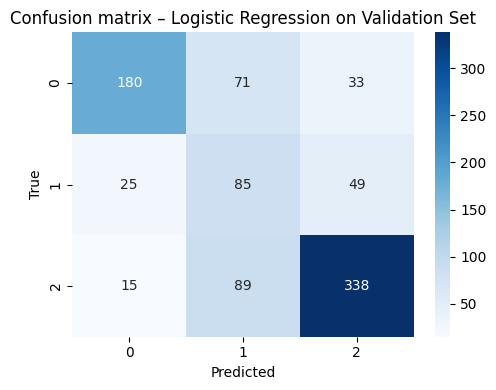

```python
lr_pred = evaluate_model(lr_clf_org_gs.best_estimator_, X_val_org, y_val_org, title="Logistic Regression on Validation Set")
```

```
=== Random Forest (Original) on Validation Set ===
Accuracy : 0.7593
Precision: 0.7071
Recall   : 0.6733
F1-score : 0.6840

Classification report:
              precision    recall  f1-score   support

     Dropout       0.84      0.72      0.78       284
    Enrolled       0.50      0.38      0.43       159
    Graduate       0.78      0.92      0.85       442

    accuracy                           0.76       885
   macro avg       0.71      0.67      0.68       885
weighted avg       0.75      0.76      0.75       885
```

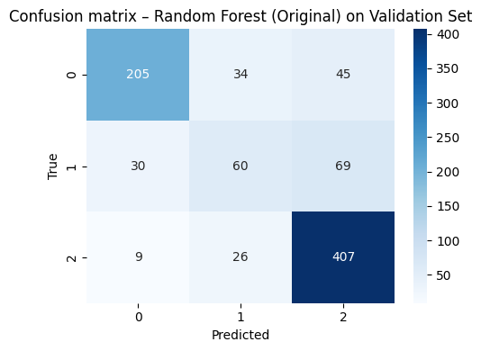

```python
rf_pred = evaluate_model(rf_clf_org_gs.best_estimator_, X_val_org, y_val_org, title="Random Forest (Original) on Validation Set")
```

```
=== Random Forest (Processed) on Validation Set ===
Accuracy : 0.7525
Precision: 0.7073
Recall   : 0.6912
F1-score : 0.6967

Classification report:
              precision    recall  f1-score   support

     Dropout       0.85      0.72      0.78       284
    Enrolled       0.47      0.48      0.48       159
    Graduate       0.80      0.87      0.83       442

    accuracy                           0.75       885
   macro avg       0.71      0.69      0.70       885
weighted avg       0.76      0.75      0.75       885
```

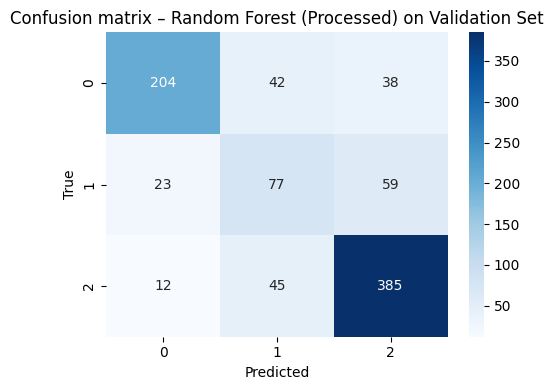

[output not shown]

[output cut: 121 more lines]

[output not shown]

```python
evaluate_model(rf_clf_proc_gs.best_estimator_, X_val_proc, y_val_proc, title="Random Forest (Processed) on Validation Set")
```

```
=== Gradient Boosting (Original) on Validation Set ===
Accuracy : 0.7254
Precision: 0.6600
Recall   : 0.6375
F1-score : 0.6447

Classification report:
              precision    recall  f1-score   support

     Dropout       0.80      0.69      0.74       284
    Enrolled       0.41      0.33      0.37       159
    Graduate       0.77      0.89      0.82       442

    accuracy                           0.73       885
   macro avg       0.66      0.64      0.64       885
weighted avg       0.72      0.73      0.72       885
```

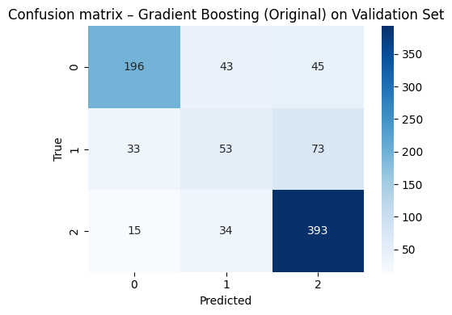

```python
gb_pred = evaluate_model(gb_clf_org_gs.best_estimator_, X_val_org, y_val_org, title="Gradient Boosting (Original) on Validation Set")
```